# ゲームハード週販レポート (2025.11.02)

国内ゲームハード週販レポート (2025-11-02)

- ハードウェアの販売データはファミ通の調査結果を基にしています。
- 一部のデータは処理上の都合により、週次値に調整しています。
- 過去の週販レポート

## 直近4週間のハード売り上げ／累計推移

Switch2の販売台数は先週の6万5千台から8万3千台と増加。累計255万台に到達しました。 このペースが年末商戦中続くことを期待したいですね。

Switchは先週より増えてます。なんで。

PS5は予想通り1万台を下回りました。セール以外はなかなか売れないですね。

| 集計日 | ハード | 販売台数 | 累計台数 |
| --- | --- | --- | --- |
| 2025-10-12 | Nintendo Switch2 | 46,842 | 2,200,903 |
|  | Nintendo Switch | 23,149 | 36,075,702 |
|  | PlayStation5 | 14,800 | 7,099,079 |
|  | Xbox Series X\|S | 237 | 685,589 |
|  | PlayStation4 | 17 | 9,490,870 |
| 2025-10-19 | Nintendo Switch2 | 201,684 | 2,402,587 |
|  | Nintendo Switch | 23,713 | 36,099,415 |
|  | PlayStation5 | 12,085 | 7,111,164 |
|  | Xbox Series X\|S | 188 | 685,777 |
|  | PlayStation4 | 23 | 9,490,893 |
| 2025-10-26 | Nintendo Switch2 | 65,434 | 2,468,021 |
|  | Nintendo Switch | 25,109 | 36,124,524 |
|  | PlayStation5 | 10,503 | 7,121,667 |
|  | Xbox Series X\|S | 991 | 686,768 |
|  | PlayStation4 | 15 | 9,490,908 |
| 2025-11-02 | Nintendo Switch2 | 83,825 | 2,551,846 |
|  | Nintendo Switch | 26,708 | 36,151,232 |
|  | PlayStation5 | 7,537 | 7,129,204 |
|  | Xbox Series X\|S | 309 | 687,077 |
|  | PlayStation4 | 18 | 9,490,926 |

## 2025年の週販推移

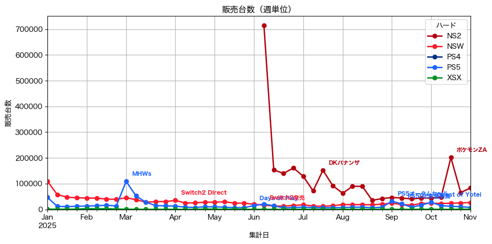

### 2025年の週販推移(拡大）

Switch2とSwitchの上昇カーブが年末商戦に向けてのものなのか来週の動きを見たいですね。 PS5については11月末にブラックフライデーセールが始まるまでは4桁維持でしょう。

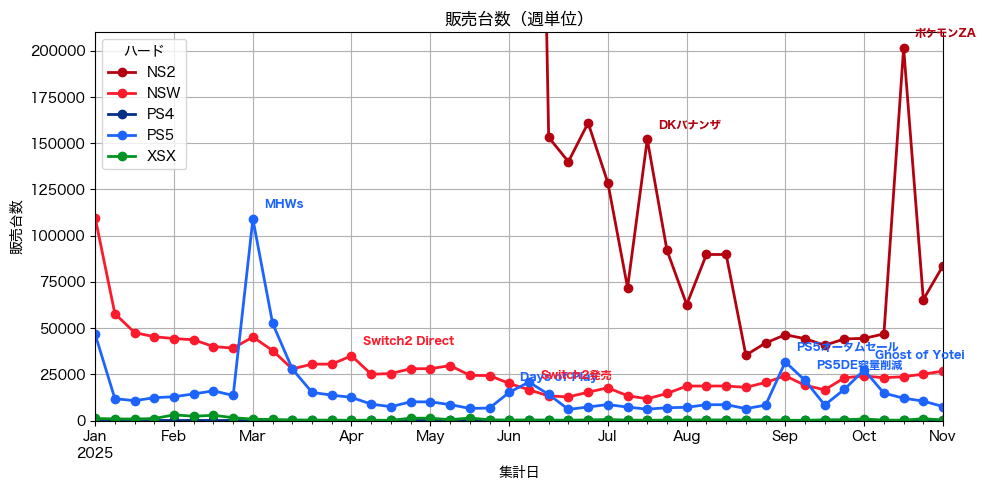

## 20年間の状況(任天堂編)

2005年から2025年10月までの各年の任天堂ハード売り上げ台数です。複数の機種がある場合は積み上げてます。

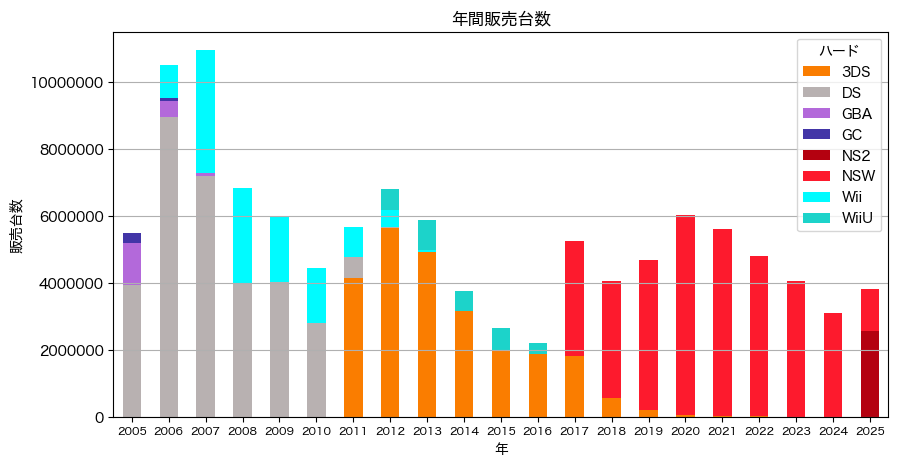

2006,2007年のDSブームは急激なものでした。 それに比べ2014年〜2016年のWiiU時代が3年連続400万台を下回っています。任天堂に危機の時代だったのが分かります。

2017年にSwitchが発売されると7年連続で400万台〜600万台を維持。 Switch末期の2024年は300万台でしたが、2025年は400万台以上は確実です。 総じてSwitch発売以降はとても安定して見えます。

今後はDSブームのような飛び跳ねるような値は無い(そもそも生産不可能でしょう)と思われますが、 今後数年は500万台前後の状況が続くと思われます。

## 2025年の月間販売推移

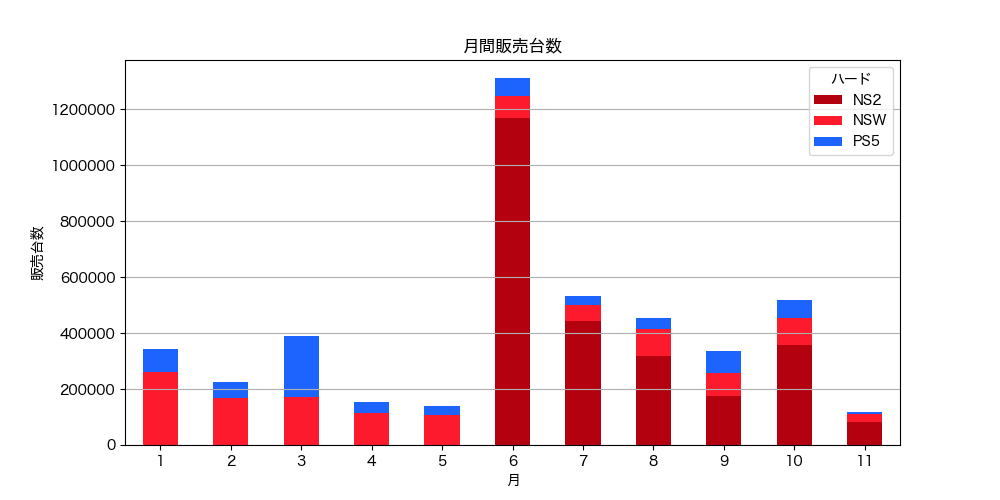

10月にはSwitch2 ZA同梱版の大量出荷がありました。ブラックフライデーを含む11月にそれを下回るとは思えません。 11月は40万台/月程度は期待したいですね。

| hw month | NS2 | NSW | PS5 |
| --- | --- | --- | --- |
| 1 | 0 | 260,447 | 81,587 |
| 2 | 0 | 167,188 | 56,886 |
| 3 | 0 | 171,921 | 218,300 |
| 4 | 0 | 113,513 | 38,983 |
| 5 | 0 | 106,506 | 32,001 |
| 6 | 1,169,684 | 78,097 | 63,516 |
| 7 | 444,706 | 57,532 | 28,959 |
| 8 | 319,690 | 94,517 | 39,004 |
| 9 | 175,542 | 82,946 | 78,693 |
| 10 | 358,399 | 96,080 | 64,732 |
| 11 | 83,825 | 26,708 | 7,537 |

### Nintendo Switchの月間販売台数： 2023,2024年との比較

Switch2大量出荷にも関わらずSwitchの販売台数は安定しています。 11月の販売台数は10月と同等か若干上回る程度と思われます。

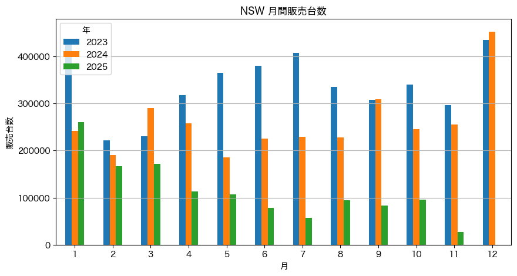

### PlayStation 5の月間販売台数： 2023, 2024年との比較

11月第1週の状況を見るに11月の前年比は酷い値になる可能性があります。 これを救うには超ビッグなセールが必要です。

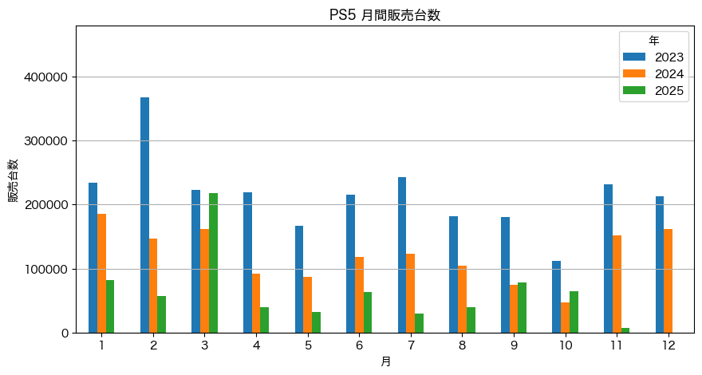

## 累計販売推移

Switch2 20万台の大量出荷がありましたが、累計グラフの見た目の変化はまだ大きくありません（右端が気持ち上がったかな程度）。 今後のSwitch2 年末商戦で変化があるでしょう。

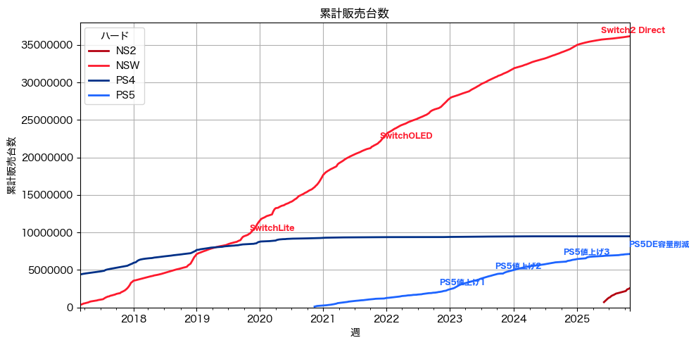

## Switch2販売状況

### 歴代機種との比較

ZA発売週の20万台がグラフの傾きにハッキリと現れています。 今後、初動歴代2位から3位に落ちる可能性はなさそうですが、 今のペースで歴代1位を超えるのは困難でしょう。

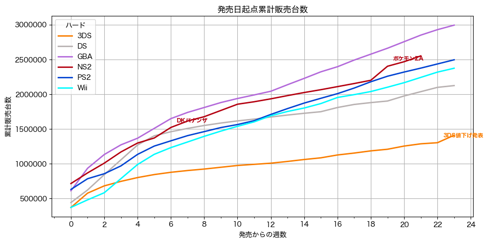

| ハード | 週数 | 販売数 |
| --- | --- | --- |
| GBA | 21 | 2,850,731 |
| NS2 | 21 | 2,551,846 |
| PS2 | 21 | 2,375,944 |
| Wii | 21 | 2,242,418 |
| DS | 21 | 2,037,178 |
| 3DS | 21 | 1,286,985 |

### 累計300万到達の見込み

| ハード | 達成年週 | 週数 | 累計販売数 |
| --- | --- | --- | --- |
| GAME BOY ADVANCE | 2001-09-09 | 24 | 3051291 |
| Wii | 2007-07-15 | 32 | 3014828 |
| Nintendo 3DS | 2011-12-11 | 41 | 3233571 |
| Nintendo DS | 2005-09-18 | 41 | 3015412 |
| PlayStation2 | 2000-12-17 | 41 | 3005742 |
| Nintendo Switch | 2017-12-24 | 42 | 3291903 |
| PocketStation | 2000-01-23 | 52 | 3011335 |
| PlayStation Portable | 2006-02-26 | 63 | 3021494 |
| Nintendo GAMECUBE | 2004-01-04 | 120 | 3115532 |
| PlayStation5 | 2023-03-05 | 120 | 3057112 |

## Switch/Switch2ロンチ比較

#### Switch2のスパイク状出荷

このまま8万〜10万台の推移が続けば年末商戦に相応しい水準といえます。 12月には20万台/週を期待したいですが、そこまで届くかどうか。

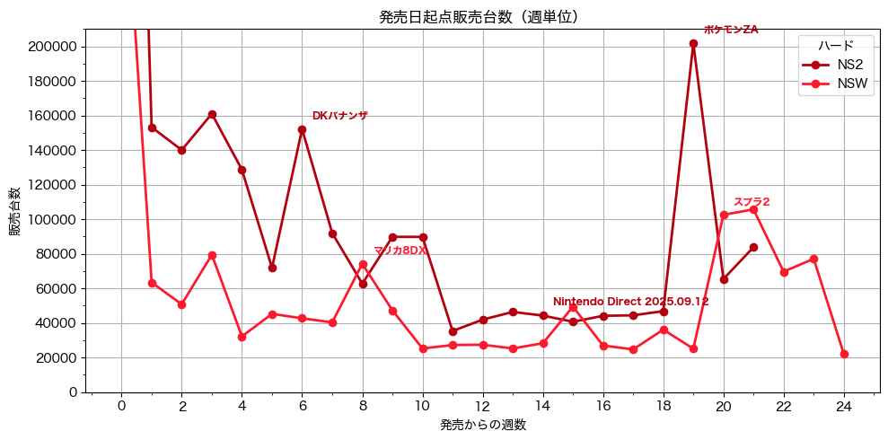

## 年単位の状況

全機種合わせた年毎のハード販売の状況です。 2024年は457万台。2025年は現時点で451万台。 来週には前年のハード出荷台数合計を超える見込みです。

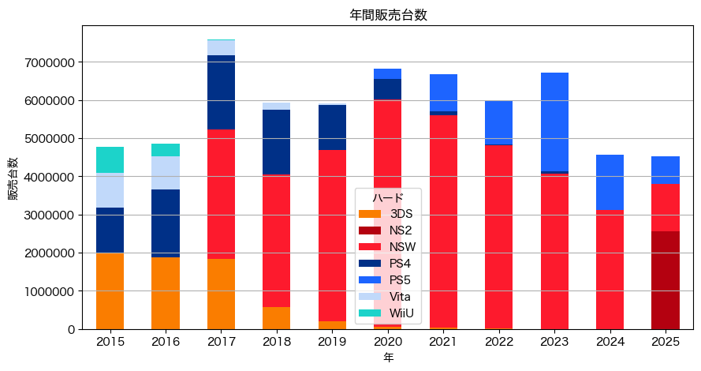